# Homework-2019.09.30

By 19086

2019-10-09

## Question 1

The Rayleigh density is
$$\begin{equation}
f(x) = \frac{x}{\sigma^2} e^{-x^2/(2\sigma^2)}, \quad\quad x\ge 0, \sigma> 0.
\end{equation}$$

Develop an algorithm to generate random samples from a Rayleigh($\sigma$) distribution. Generate Rayleigh($\sigma$) samples for several choices of $\sigma>0$ and check that the mode of the generated samples is close to the theoretical mode $\sigma$ (check the histogram).

## Question 2

Generate a random sample of size $1000$ from a normal location mixture. The components of the mixture have $N(0, 1)$ and $N(3, 1)$ distributions with mixing probabilities $p_1$ and $p_2 = 1 − p_1$. Graph the histogram of the sample with density superimposed, for $p_1 = 0.75$. Repeat with different values for $p_1$ and observe whether the empirical distribution of the mixture appears to be bimodal. Make a conjecture about the values of $p_1$ that produce bimodal mixtures.

## Question 3

Write a function to generate a random sample from a $W_d(\Sigma, n)$ (Wishart) distribution for $n > d + 1 ≥ 1$, based on Bartlett’s decomposition.

## Answer 1

Aalgorithm: acceptance-rejection.

Let $g(x)$ be the $Uniform(0,1)$ density. The upper bound $c$ of $f(x)/g(x)$ is $1/\sigma^2$, so $c=1/\sigma^2$.

```r
set.seed(1111)
library(ggplot2)
Rayleigh_arm <- function(n, sigma){
  # n is siaze of number, sigma is parameter
  Rayleigh_pdf <- function(x){
    # define the pdf of Rayleigh distribution
    x * exp(-x*x/(2*sigma*sigma)) / sigma*sigma
  }
  j <- 0 # the time of iteration
  k <- 0 # the available sample
  y <- numeric(n) # a zero vector of length n
  while (k < n){
    u <- runif(1)
    j <- j + 1
    x <- runif(1) # random variate from g
    if (exp(-x*x/(2*sigma*sigma))*(1-x*x/sigma/sigma) > u) {
      # accept x
      k <- k + 1
      y[k] <- x
    }
  }
  return(y)
}
Len = 10000
sigma = 10
sample_Rayleigh <- Rayleigh_arm(Len, sigma) # record the sample
head(sample_Rayleigh, 20)
```

```
##  [1] 0.41292487 0.13710541 0.97632700 0.11678428 0.14011597 0.74895750
##  [7] 0.63340635 0.15936303 0.55700675 0.76588707 0.42121847 0.98737065
## [13] 0.40557686 0.38555472 0.21639342 0.93122816 0.35914389 0.02617067
## [19] 0.11346912 0.01833906
```

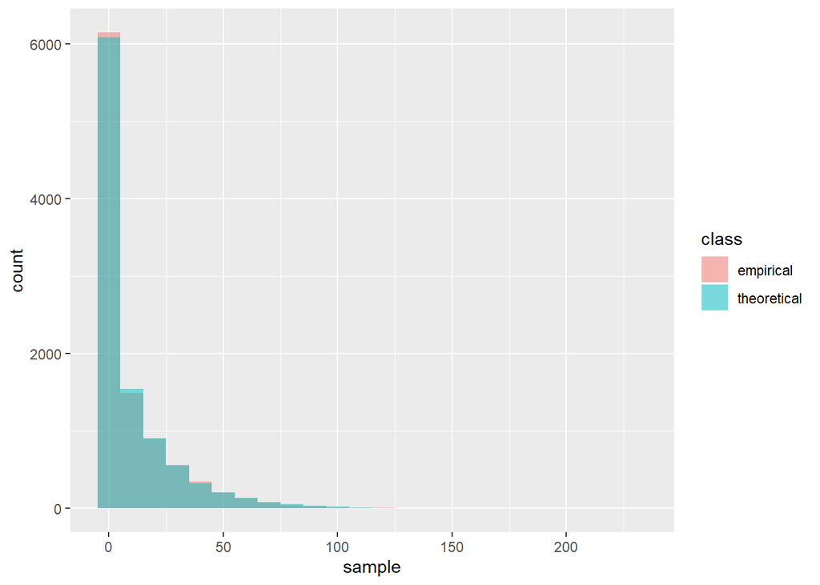

```r
#generate the sample by using Inverse Transform Method
u = runif(Len);
sample_Rayleigh_theo = -2*sigma*(log(1-u));
data_Rayleigh <- data.frame(sample = c(sample_Rayleigh,sample_Rayleigh_theo),class = rep(c('empirical','theoretical'),each = 1000))#construst a data frame in order to generate a figure
ggplot(data_Rayleigh,aes(x = sample,fill = class))+geom_histogram(position="identity", alpha=0.5, binwidth = 10)
```

## Answer 2

**Algorithm:**

1. input $p_1$
2. generate an integer $k\in\{1,2\}$, where $P(1) = 1- P(2) = p_1$
3. if $k=1$ deliver $x$ from $N(0,1)$

   if $k=2$ deliver $x$ from $N(3,1)$

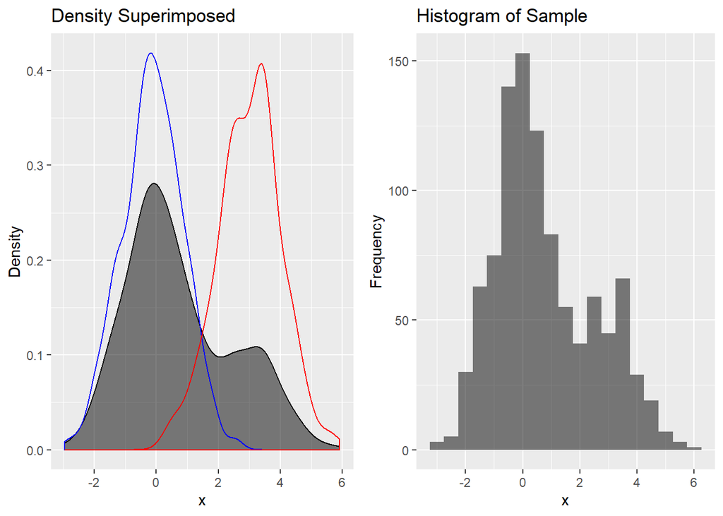

```r
set.seed(1111)
mix_fun <- function(p1){
  n <- 1000
  prob <- c(p1, 1-p1)
  k <- sample(1:2, size=n,replace=TRUE, prob=prob)
  x <- rep(0, n)
  x[k==1] <- rnorm(length(which(k==1)), mean=0, sd=1)
  x[k==2] <- rnorm(length(which(k==2)), mean=3, sd=1)
  return (list(x=x, k=k))
}
draw <- function(mix_data, k){
  dat1 <- data.frame(data=mix_data, class = rep('Mixture',each = 1000))
  dat2 <- data.frame(data=mix_data[k==1], class = rep('C1',each = length(which(k==1))))
  dat3 <- data.frame(data=mix_data[k==2], class = rep('C2',each = length(which(k==2))))
  pic <- ggplot() + labs(x="x",y="Density",color='black') + ggtitle("Density Superimposed")
  pic <- pic + geom_density(data=dat1, aes(x=data), position="identity", fill='black', alpha=0.5, show.legend = TRUE)
  pic1 <- ggplot() + geom_histogram(data=dat1, aes(x=data), binwidth = 0.5,position="identity", fill='black', alpha=0.5, show.legend = TRUE) + labs(x="x",y="Frequency",color='black') + ggtitle("Histogram of Sample")
  pic <- pic +geom_density(data=dat2, aes(x=data), position="identity", color='blue', alpha=0.3, show.legend = TRUE)
  pic <- pic +geom_density(data=dat3, aes(x=data), position="identity", color='red', alpha=0.3, show.legend = TRUE)
  multiplot(pic, pic1, cols=2)
}
re <- mix_fun(0.75)
mix_data <- re$x; k <- re$k
draw(mix_data, k)
```

The left pannel shows the emperical distribution of different compoent and the emperical distribution of the mixture (filled region) as well as the histogram of the sample in the right pannel.

Now, let’s repeat the experiment with different values for $p_1$. Let $p_1=0.3,0.5,0.9$

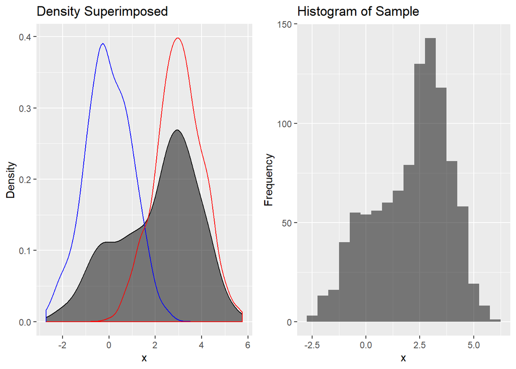

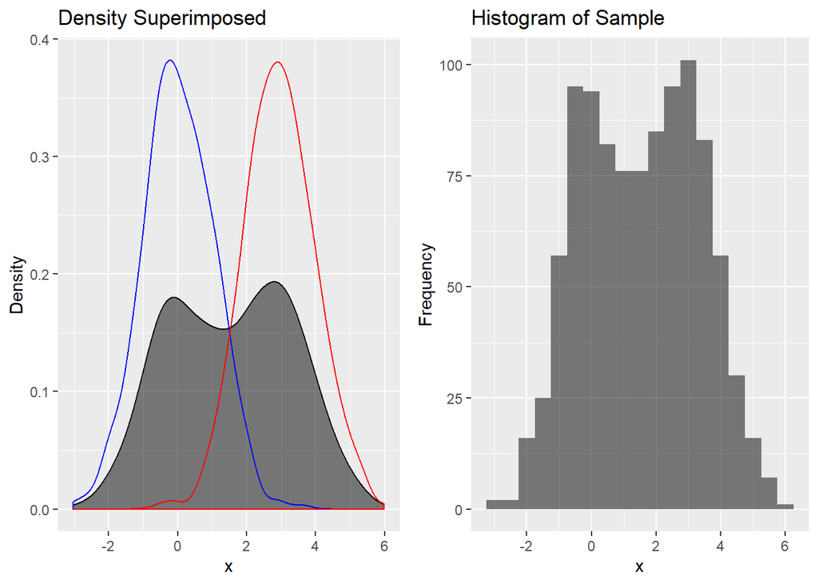

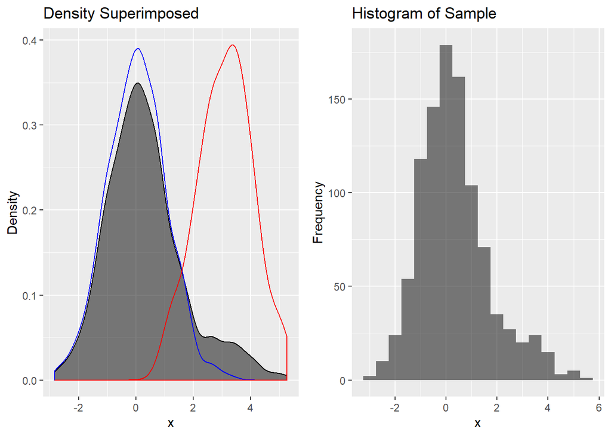

```r
p1=c(0.3,0.5,0.9)
for (p in p1) {
  re <- mix_fun(p)
  mix_data <- re$x; k <- re$k
  draw(mix_data, k)
}
```

## Answer 3

According to the textbook (page 80), we know that let $T = (T_{ij})$ be a lower triangular $d \times d$ random matrix with independent entries satisfying

1. $T_{i,j}\sim N(0,1), i>j, \; iid$
2. $T_{i,i}\sim\sqrt{\chi^2(n-i+1)}, i=1,...,d, \; iid$.

Then the matrix $A = TT^T$ has a $W_d(I_d, n)$ distribution. To generate $W_d(\Sigma, n)$ random variates, obtain the Choleski factorization $\Sigma = LL^T$ , where $L$ is lower triangular. Then $LAL^T ∼ W_d(\Sigma, n)$.

```r
wishart <- function(n,d,Sig){
  T <- matrix(rep(0,d*d), nrow=d)
  for (ii in 1:d) {
    for (jj in 1:ii) {
      T[ii,jj] <- rnorm(1)
    }
    T[ii,ii] <- sqrt(rchisq(1,n-ii+1))
  }
  A <- T %*% t(T)
  L <- t(chol(Sig))
  x <- L %*% A %*% t(L)
  return(x)
}
n <- 100
d <- 10
Sig <- matrix(rep(0,d*d), nrow=d)
  for (ii in 1:d) {
    for (jj in 1:d) {
      Sig[ii,jj] <- 0.5^abs(ii-jj)
    }
  }
x <- wishart(n,d,Sig)
head(x)
```

```
##           [,1]     [,2]     [,3]      [,4]       [,5]       [,6]      [,7]
## [1,] 90.925265 44.54831 31.75625  9.637724   2.924342   7.663547 -3.997919
## [2,] 44.548306 78.23558 45.86084 11.807922  20.600605  22.965701 10.939964
## [3,] 31.756253 45.86084 91.91679 38.898818  24.378116  18.130826 16.927466
## [4,]  9.637724 11.80792 38.89882 91.434138  63.363310  45.247399 17.998832
## [5,]  2.924342 20.60061 24.37812 63.363310 114.806793  67.902289 34.596362
## [6,]  7.663547 22.96570 18.13083 45.247399  67.902289 136.141458 61.098734
##            [,8]        [,9]     [,10]
## [1,] -12.896013  -3.7944313 -8.788777
## [2,]  -5.058735   1.0382111  4.626381
## [3,]   8.041067  -6.2456563 -8.770270
## [4,]  -1.790936 -11.9477855 -9.563261
## [5,]  10.574631  -5.7904254  7.597465
## [6,]  18.184598   0.5599001 -2.243568
```

The function **wishart** is all we need, its input is $n$, $d$ and $\Sigma$.

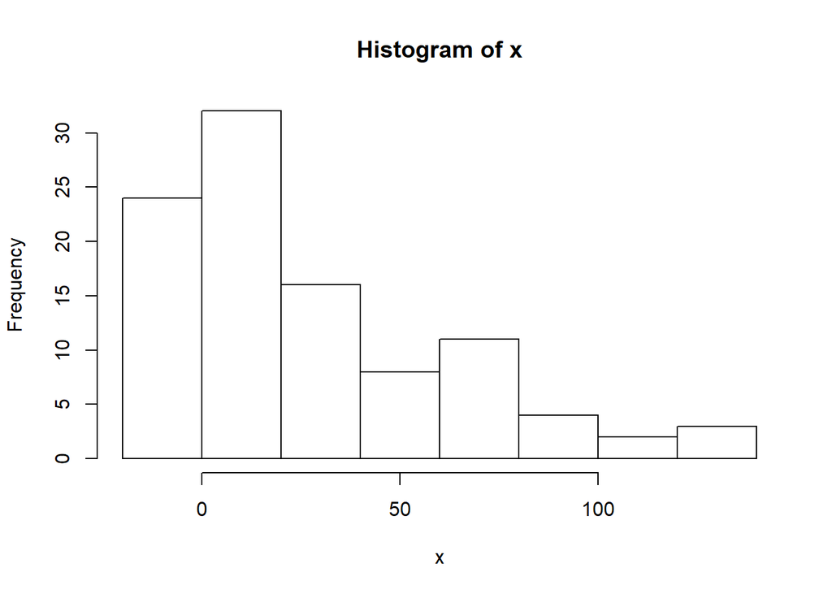

```r
hist(x)
```